# Data Visualisation Project

# 1) Import the necessary packages

# 2) Load the dataset

| Employee_Name | EmpID | MarriedID | MaritalStatusID | GenderID | EmpStatusID | DeptID | PerfScoreID | FromDiversityJobFairID | Salary | Termd | PositionID | Position | State | Zip | DOB | Sex | MaritalDesc | CitizenDesc | HispanicLatino | RaceDesc | DateofHire | DateofTermination | TermReason | EmploymentStatus | Department | ManagerName | ManagerID | RecruitmentSource | PerformanceScore | … |
| --- | --- | --- | --- | --- | --- | --- | --- | --- | --- | --- | --- | --- | --- | --- | --- | --- | --- | --- | --- | --- | --- | --- | --- | --- | --- | --- | --- | --- | --- | --- |
| Adinolfi, Wilson K | 10026 | 0 | 0 | 1 | 1 | 5 | 4 | 0 | 62506 | 0 | 19 | Production Technician I | MA | 01960 | 07/10/83 | M | Single | US Citizen | No | White | 7/5/2011 | NA | N/A-StillEmployed | Active | Production | Michael Albert | 22 | LinkedIn | Exceeds | … |
| Ait Sidi, Karthikeyan | 10084 | 1 | 1 | 1 | 5 | 3 | 3 | 0 | 104437 | 1 | 27 | Sr. DBA | MA | 02148 | 05/05/75 | M | Married | US Citizen | No | White | 3/30/2015 | 6/16/2016 | career change | Voluntarily Terminated | IT/IS | Simon Roup | 4 | Indeed | Fully Meets | … |
| Akinkuolie, Sarah | 10196 | 1 | 1 | 0 | 5 | 5 | 3 | 0 | 64955 | 1 | 20 | Production Technician II | MA | 01810 | 09/19/88 | F | Married | US Citizen | No | White | 7/5/2011 | 9/24/2012 | hours | Voluntarily Terminated | Production | Kissy Sullivan | 20 | LinkedIn | Fully Meets | … |
| Alagbe,Trina | 10088 | 1 | 1 | 0 | 1 | 5 | 3 | 0 | 64991 | 0 | 19 | Production Technician I | MA | 01886 | 09/27/88 | F | Married | US Citizen | No | White | 1/7/2008 | NA | N/A-StillEmployed | Active | Production | Elijiah Gray | 16 | Indeed | Fully Meets | … |
| Anderson, Carol | 10069 | 0 | 2 | 0 | 5 | 5 | 3 | 0 | 50825 | 1 | 19 | Production Technician I | MA | 02169 | 09/08/89 | F | Divorced | US Citizen | No | White | 7/11/2011 | 9/6/2016 | return to school | Voluntarily Terminated | Production | Webster Butler | 39 | Google Search | Fully Meets | … |
| Anderson, Linda | 10002 | 0 | 0 | 0 | 1 | 5 | 4 | 0 | 57568 | 0 | 19 | Production Technician I | MA | 01844 | 05/22/77 | F | Single | US Citizen | No | White | 1/9/2012 | NA | N/A-StillEmployed | Active | Production | Amy Dunn | 11 | LinkedIn | Exceeds | … |

# 3) About the data

```
## Rows: 311
## Columns: 36
## $ Employee_Name              <chr> "Adinolfi, Wilson  K", "Ait Sidi, Karthikey…
## $ EmpID                      <dbl> 10026, 10084, 10196, 10088, 10069, 10002, 1…
## $ MarriedID                  <dbl> 0, 1, 1, 1, 0, 0, 0, 0, 0, 0, 1, 1, 0, 0, 0…
## $ MaritalStatusID            <dbl> 0, 1, 1, 1, 2, 0, 0, 4, 0, 2, 1, 1, 2, 0, 2…
## $ GenderID                   <dbl> 1, 1, 0, 0, 0, 0, 0, 1, 0, 1, 0, 1, 1, 1, 1…
## $ EmpStatusID                <dbl> 1, 5, 5, 1, 5, 1, 1, 1, 3, 1, 5, 5, 1, 1, 5…
## $ DeptID                     <dbl> 5, 3, 5, 5, 5, 5, 4, 5, 5, 3, 5, 5, 3, 5, 5…
## $ PerfScoreID                <dbl> 4, 3, 3, 3, 3, 4, 3, 3, 3, 3, 3, 3, 4, 3, 3…
## $ FromDiversityJobFairID     <dbl> 0, 0, 0, 0, 0, 0, 0, 0, 1, 0, 1, 1, 1, 0, 0…
## $ Salary                     <dbl> 62506, 104437, 64955, 64991, 50825, 57568, …
## $ Termd                      <dbl> 0, 1, 1, 0, 1, 0, 0, 0, 0, 0, 1, 1, 0, 0, 1…
## $ PositionID                 <dbl> 19, 27, 20, 19, 19, 19, 24, 19, 19, 14, 19,…
## $ Position                   <chr> "Production Technician I", "Sr. DBA", "Prod…
```

[output cut: 23 more lines]

# 4) Research questions:

1. Is there any relation between gender and salary in each department?
2. Is there any relation between race and salary in each department?
3. Show the evolution of the sources of recruiting over time.

# 5) Data cleaning

- Select only the columns that we need
- Sum of rows that contain NA values
- Remove all rows that contain NA values
- Encode the RaceDesc column
- Convert the date in type chr to date format
- Create columns Month-Yr and Yr of the DateofHire data
- Order the Sex data by its total number
- Order the Department data by the number of workers in it
- Order the RaceDesc data by its total number
- Order the RaceDescID data by its total number
- Order the RecruitmentSource data by its total number

# 6) Visualization between Gender and Salary in the company

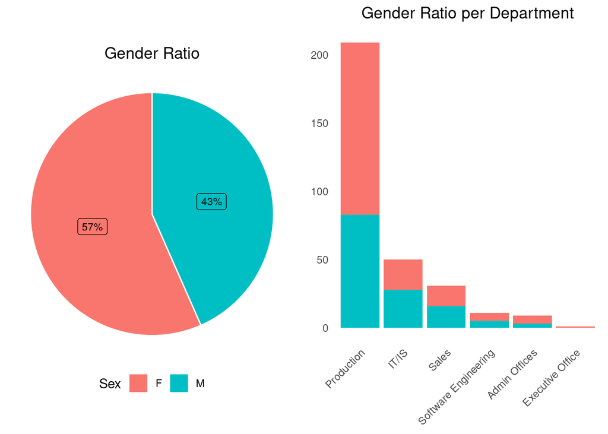

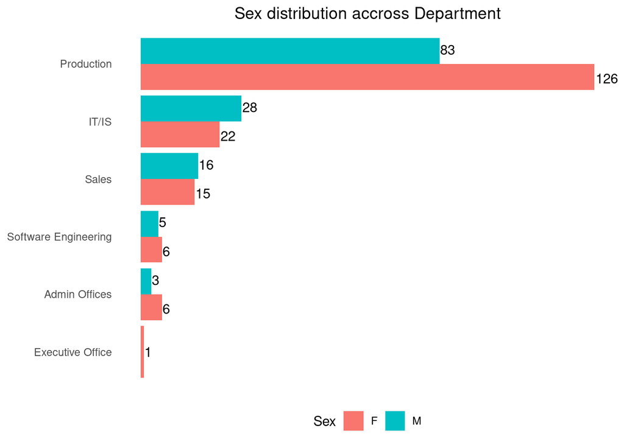

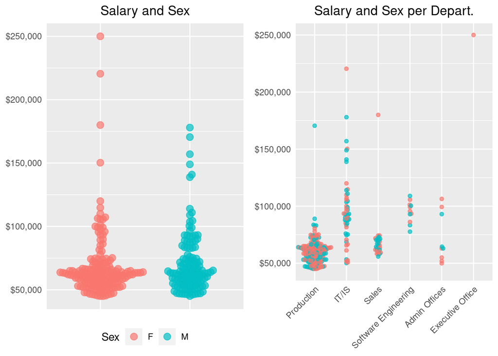

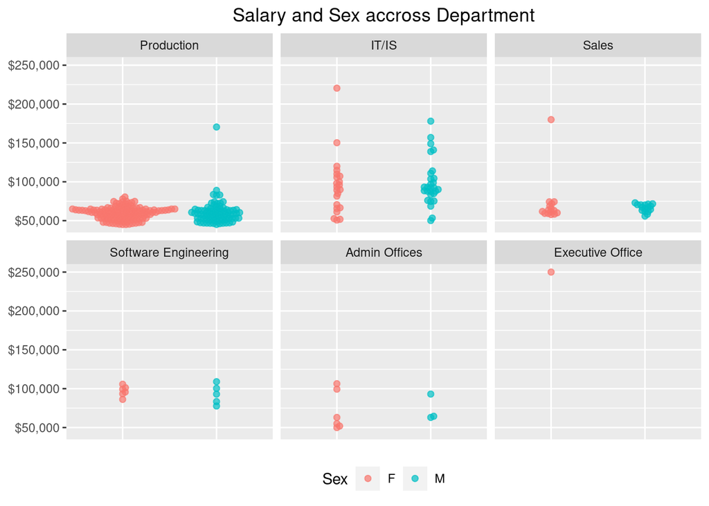

CONCLUSION: Fortunately, the Sex variable is more likely balanced in our data, We can observe the similarity in the distribution of Salary in each department between Male and Female. We can also see few outliers.

# 7) Visualization between Race and Salary in the company

[figure not shown]

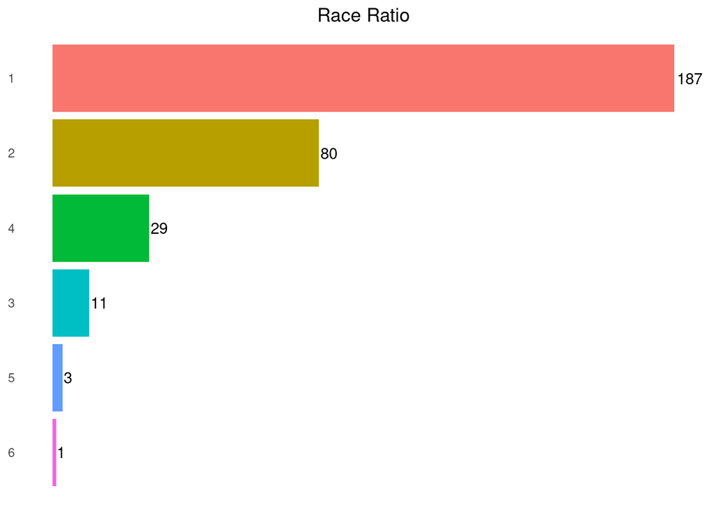

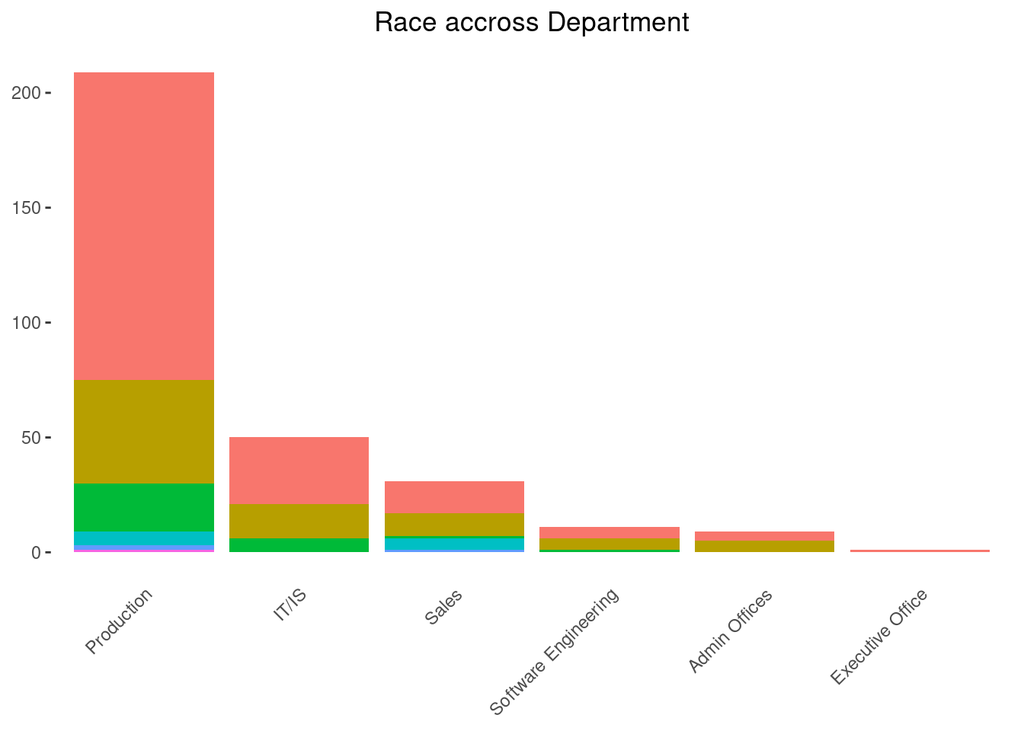

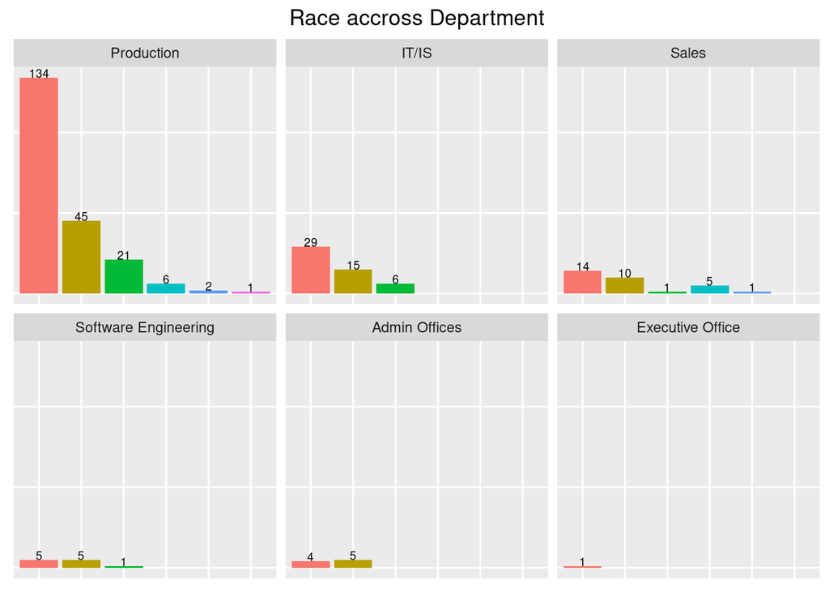

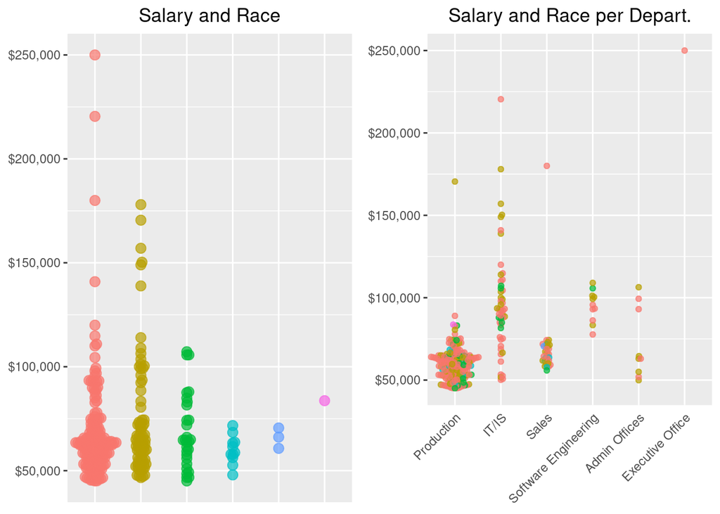

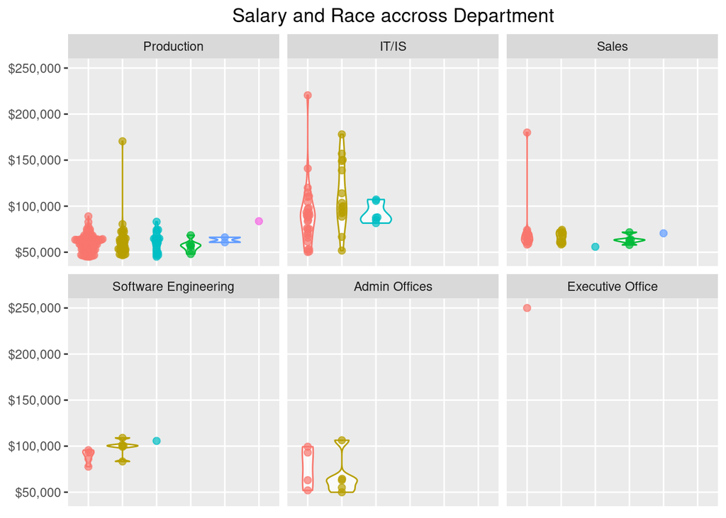

CONCLUSION: It is difficult to see the relationship between Race and Salary because of the Race ratio. Indeed, in our data, we can see 187 Whites compared to 3 American Indian or 1 Hispanic. Hence, for this study, we need more data.